# Effectively and accurately mapping global biodiversity patterns for different regions and taxa - Hughes - - Global Ecology and Biogeography - Wiley Online Library

[Global Ecology and Biogeography](https://onlinelibrary.wiley.com/journal/14668238)

[Early View](https://onlinelibrary.wiley.com/toc/14668238/0/0)

RESEARCH PAPER

Full Access

# Effectively and accurately mapping global biodiversity patterns for different regions and taxa

[Alice C. Hughes](https://onlinelibrary.wiley.com/action/doSearch?ContribAuthorStored=Hughes%2C+Alice+C)

[Michael C. Orr](https://onlinelibrary.wiley.com/action/doSearch?ContribAuthorStored=Orr%2C+Michael+C)

[Qinmin Yang](https://onlinelibrary.wiley.com/action/doSearch?ContribAuthorStored=Yang%2C+Qinmin)

[Huijie Qiao](https://onlinelibrary.wiley.com/action/doSearch?ContribAuthorStored=Qiao%2C+Huijie)

First published: 22 April 2021

https://doi.org/10.1111/geb.13304

Michael C. Orr: Contributed equally.

## Abstract

### Aim

The aim was to understand the representativeness and accuracy of expert range maps and to explore alternative methods for mapping species distributions accurately.

### Location

Global.

### Time period

Contemporary.

### Major taxa studied

Terrestrial vertebrates and Odonata.

### Methods

We analysed the biases in 50,768 animal International Union for Conservation of Nature, Global Assessment of Reptile Distributions and BirdLife species maps and assessed the links between these maps and existing political boundaries and various non‐ecological boundaries to assess their accuracy for certain types of analyses. We cross‐referenced each species map with data from the Global Biodiversity Information Facility to assess whether maps captured the whole range of a species and what percentage of occurrence points fell within the assessed range of the species. In addition, we used a number of different methods to map diversity patterns and compared these with high‐resolution models of distribution patterns.

### Results

On average, 20–30% of the non‐coastal range boundaries of species overlapped with administrative national boundaries. In total, 60% of areas with the highest spatial turnover in species (high densities of species range boundaries marking high levels of shift in the community of species present) occurred at political boundaries, which was especially common in Southeast Asia. Different biases existed for different taxa, with gridded analysis in reptiles, river basins in Odonata (except the Americas) and county boundaries for amphibians in the USA. On average, up to half (25–46%) of the recorded range points of species fell outside their mapped distributions. Filtered minimum convex polygons performed better than expert range maps in reproducing modelled diversity patterns.

### Main conclusions

Expert range maps showed high bias at administrative borders in all taxa, but this was highest at the transition from tropical to subtropical regions. The methods used were inconsistent across space, time and taxa, and the ranges mapped did not match species distribution data. Alternative approaches can reconstruct patterns of distribution better than expert maps, and data‐driven approaches are needed to provide reliable alternatives to gain a better understanding of species distributions.

## 1 INTRODUCTION

Understanding species distributions is a fundamental aspect of conservation and management. Accurate maps of species distributions enable assessment of conservation priorities world‐wide and facilitate the development of targeted conservation strategies (Jung et al., 2020). Thus, to perform such prioritizations or gap analyses, it is crucial that species ranges are spatially accurate. In the last two decades, range maps from the International Union for Conservation of Nature (IUCN) and similar publically available sources have been used regularly for the assessment of species distributions across scales (Jenkins et al., 2013; Jetz et al., 2012). Subsequently, vast amounts of conservation funding have been allocated based on these range maps (Brooks et al., 2019). Although these maps have been created for various purposes by different groups, they are now used for global biodiversity analyses, and little has been done to test whether they are truly fit for this purpose. Understanding these biases is especially important, because despite existing guidelines from the IUCN, checklists and other types of species data may be used to delimit species ranges, and this might misrepresent real species richness patterns if explored at high resolutions.

Species range modelling is highly sensitive to the data and methods adopted and, if using species range maps, whether and how they are trimmed or filtered to reflect local environmental conditions. For instance, even basic methods to trim species IUCN ranges using habitat or elevation preferences can reduce their range area enough to change the Red List status of many species (Li et al., 2016; Ocampo‐Peñuela et al., 2016). The reliability of species diversity maps is crucial not only to apportion adequate and appropriate conservation efforts, but also to understand even basic biodiversity patterns. Errors in these types of assessments, such as the use of administrative areas with checklists rather than high‐resolution maps of species ranges, could highlight the wrong areas of richness or occurrences of rare species and, with limited resources available, this translates to failures to conserve areas and ecosystems critically in need of protection.

Unfortunately, accurate and reliable data are rare for most taxonomic groups owing to intense sampling biases (Hughes et al., 2020). As a consequence, IUCN and similar data underlie countless studies, including those on distribution (Buckley & Jetz, 2008; Holt et al., 2013; Rissler & Smith, 2010), climate change (Akcakaya et al., 2006; Sandel et al., 2011; Sekerciuglu et al., 2012) and, especially, conservation (Betts et al., 2017; Brooks et al., 2019; Jenkins et al., 2013, 2015; Jetz et al., 2014; La Saout et al., 2013; Li et al., 2017; Mason et al., 2020; Meyer et al., 2015; Moran & Kanemoto, 2017; Ocampo‐Peñuela et al., 2016; Pouzols et al., 2014; Runge et al., 2015). These studies include analyses at various resolutions, although 10 km<sup>2</sup> is a common resolution in many projects as “richness maps” based on the same source expert range map (ERM) data as this study are made publically available for download and analysis at a 10 km<sup>2</sup> resolution (https://biodiversitymapping.org). Guidance states that distribution data should be used in developing species range polygons, yet the adherence to these guidelines (which, for example, expressly state not to buffer single points as a range) is not apparent (https://www.conservationtraining.org/enrol/index.php?id=156). In order to mitigate the risks of misrepresenting a species’ range, researchers should carefully assess the limitations of their data before applying them to real‐world issues, such as developing priorities for conservation.

An immense amount of work has gone into making these ERMs, and they hold great potential for informing conservation decisions, but assessments on their broader applicability are lacking. Here, we test the widespread assumption that the most up‐to‐date ERMs (for mammals, odonates (dragonflies and damselflies), amphibians, birds and reptiles) provide consistent and standardized species range estimates. Clearly, consistency in approaches is needed to compare richness patterns meaningfully between regions and taxa, because inconsistent approaches could result in changes in patterns as a consequence of methodological changes and could not be differentiated from genuine changes in richness patterns. We assessed whether these range boundaries were representative of species occurrence or were instead associated with administrative borders. We also assessed the proportion of filtered species occurrence records, based on data recorded in the Global Biodiversity Information Facility (GBIF)] falling within the designated ERM for each species. We discuss alternative methods of mapping diversity patterns and demonstrate the trade‐off between different approaches and the limits of applications for each. Understanding biases and inconsistencies between species occurrence and reported range maps can help to inform appropriate use of these ERMs and ensure that these data are fit for this purpose. Our goal is to inform the conservation community to make better use of available data and to inform research and management decisions effectively, based on a clearer understanding of species and richness patterns.

## 2 MATERIALS AND METHODS

We use a combination of approaches to explore the relationship between species range maps and geopolitical boundaries and a subset of geographical features. In some cases, we used the density of species range boundaries to explore the relationship between these and various features (e.g., administrative boundaries, river basin boundaries). Additionally, species richness and spatial turnover are used to explore changes in richness over short geographical distances. Analyses were conducted in R statistical software unless noted otherwise. All code scripts are available at https://github.com/qiaohj/iucn_fix. Workflows are shown in the Supporting Information (Figure S1a–c, with associated scripts listed).

### 2.1 Species ranges and boundary density maps

Expert range maps were downloaded from the IUCN Red List website for mammals (5,709 species), odonates (2,239 species) and amphibians (6,684 species; [https://www.iucnredlist.org/resources/grid/spatial‐data](https://www.iucnredlist.org/resources/grid/spatial-data)). Shapefile maps for birds were downloaded from BirdLife (10,423 species; http://datazone.birdlife.org/species/requestdis) and for reptiles from the Global Assessment of Reptile Distributions (GARD) (10,064 species; Roll et al., 2017). The polygon boundaries for each species were converted to a polylines to show the boundary of each species range (Supporting Information Figure S1a‐II; coding in lines 7–18 of line2raster_xxxx.r; xxxx varies based on the taxon). The associated shapefile was then split to produce independent polyline files for each species within each taxon (see Supporting Information Figure S1a‐I; codes are lines 29–83 in the same file above).

To generate species boundary density maps, species range boundaries were rasterized at 1 km spatial resolution with an equal area projection (Eckert IV) and stacked to form a single raster for each taxon (at the level of amphibians, odonates, etc.). This represented the number of species in each group and their overlapping range boundaries (Supporting Information Figure S1b‐II; codes are in line2raster_all.r). The value in each cell indicated the number of species whose distribution boundaries overlapped with each cell, enabling us to overlay this rasterized information with other features (i.e., administrative boundaries) such that the overlaps between them could be calculated in R. These species boundary density maps underlie most subsequent analyses. R code and caveats are given in the Supporting Information, and links are provided in text and the Supporting Information (Figure S1).

### 2.2 Geographical boundaries

Spatial exploration of species range boundaries in ArcGIS suggested that numerous geographical datasets (i.e., political and, in a few cases, geographical features, such as river basins) were used to delineate the species ranges for different regions and taxa (this is sometimes part of the methodology in developing ERMs, as detailed by Ficetola et al., 2014). Thus, in addition to analysing the administrative bias and the percentage of occurrence records within each species’ ERM for all taxa, additional analyses were conducted when other biases were evident in any given taxon or region (detailed later in the methods on a case‐by‐case basis).

For all taxa, we assessed the percentage of overlap between species range boundaries and national and provincial boundaries by digitizing each to 1 km (equivalent to buffering the polyline by 500 m), both with and without coastal boundaries. An international map was used because international (Western) assessors use them and does not necessarily denote agreed country boundaries (https://gadm.org/). The different buffers (500, 1,000, 2,500 and 5,000 m) were added to these administrative boundaries in ArcMap 10.3 (ESRI; https://www.r-project.org/) to account for potential, insignificant deviations from political boundaries (Supporting Information Figure S1b). An R script for the same function is provided in “country_line_buffer.r”.

To establish where multiple species shared range boundaries, we reclassified the species range boundary density rasters for each taxon into richness classes using the ArcMap quartile function (Supporting Information Figure S1). From these 10 classes, the percentage of the top two and top three quartiles of range densities within different buffers (500, 1,000, 2,500 and 5,000 m) was calculated per country to determine what percentage of highest range boundary density approximately followed administrative borders. This was done because people drawing ERMs might use detailed administrative maps or generalize near political borders or might use political shapefiles that deviate slightly. Consequently, it is useful to include various distances from administrative features to assess how range boundary densities vary in relationship to administrative boundaries. Analyses of relationships between individual species range boundaries and administrative boundaries (coastal and non‐coastal) were made in R and scripts provided (quantile_country_buffer_overlap.r).

### 2.3 Spatial turnover and administrative boundaries

Heat maps of species richness were generated by summing entire sets of compiled species ranges for each taxon in polygonal form (Figure 1; Supporting Information Figure S1b‐I). To assess abrupt changes in diversity, standard deviations for 10 km blocks were calculated using the block statistics function in ArcMap. Abrupt changes in diversity were signified by high standard deviations based on the cell statistics function in ArcGIS, which represented rapid changes in the number of species present. Maps were then classified into 10 categories using the quartile function. Given the high variation in maximum diversity and taxonomic representation, only the top two or three richness categories were retained per taxon. This was then extracted using 1 km buffers of national administrative boundaries to assess percentages of administrative boundaries overlapping turnover hotspots by assessing the proportion of political boundaries that were covered by these turnover hotspots.

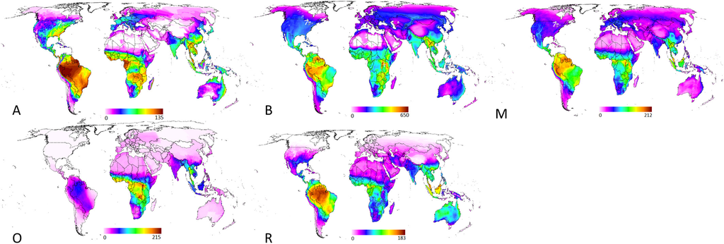

**FIGURE 1**

Heat maps of species richness based on expert range map data for each taxon. The values given represent the number of species per taxon in a 1 km grid cell. Gridding for reptile data is clearly visible in Africa, and U.S. county boundaries are visible in amphibian data. Provinces for India and Australia show in Odonata. The Supporting Information (Figure S2) provides a higher resolution version of these issues. A = amphibians; B = birds; M = mammals; O = Odonata; R = reptiles

### 2.4 Taxon‐specific analyses

Data exploration and mapping exposed taxon‐ and region‐specific biases requiring additional analysis. Where other biases and irregularities were clear from visual inspection of the range boundary density maps for each taxon, the possible causes of biases were assessed by comparing range boundary density maps with high‐resolution imagery and administrative maps via the ArcGIS server (http://services.arcgisonline.com/ArcGIS/services). Standardized overlay of the taxon boundary sets with administrative or geophysical features from the image server revealed three types of bias that were limited either spatially or taxonomically between: (a) amphibians with county borders in the USA, (b) dragonflies and river basins globally, and (c) gridding of distributions of reptiles. In these cases, species boundary density maps were used as a basis to identify potential biases, which were then explored empirically using appropriate methods.

For amphibians, counties in the USA were digitized using a county map from the USA (https://gadm.org/), then buffered by 2.5 km either side. Amphibian species range boundary density maps were reclassified, showing where species range boundaries existed (with other non‐range boundary areas reclassified as “no data”), and all species boundaries were indicated numerically (i.e., a value of one indicates one species range boundary, and a value of 10 indicates 10 species range boundaries). Percentages of species boundary areas falling on county boundaries and in the buffers, in addition to species range boundaries that did not overlap with county boundaries, were calculated to give measures of the percentage of the species boundaries that fell within 2.5 km of county boundaries.

For Odonata, many species were mapped to river basin borders. We used river basins of levels six to eight (sub‐basin to basin) in the river hierarchy (https://hydrosheds.org) to assess the relationship between Odonata boundaries and river boundaries. Two IUCN datasets exist for Odonata: the IUCN Odonata specialist group spatial dataset ([https://www.iucnredlist.org/resources/spatial‐data‐download](https://www.iucnredlist.org/resources/spatial-data-download)), and a larger dataset available via the Red List website ([https://www.iucnredlist.org/resources/grid/spatial‐data](https://www.iucnredlist.org/resources/grid/spatial-data)) containing an additional 1,000 polygons relative to the previous file (as of September 2019), predominately in Latin America (and often showing extensions of species ranges or range fragments rather than 1,000 additional species). We examined both, because either might be used for contemporary analyses on Odonata.

For reptiles, two grid resolutions were visible when mapping species range boundary density (1 and 0.5 decimal degrees; Supporting Information Figure S2c shows these grids and why further analysis was conducted). Gridding in range delineation was examined by developing 1 and 0.5° fishnet grids globally (matching the observed grid resolutions). Grids were then aligned with the noted reptile range boundary grids in central Africa (the closest area to 0, 0); if grids were not a genuine artefact of digitization, this would not be possible, or it would be inconsistent in different regions (alignment between the digitized fishnet grid and range boundaries was reconfirmed in Central Asia and South America). Grids were then clipped to land areas and merged with national political boundaries into a combined shapefile. Species range boundary density was quantified, and layers were reclassified for areas where more than three species boundaries overlapped; this was then intersected with both grid sizes to quantify percentages of boundary hotspots overlapping with grids or national borders.

### 2.5 GBIF cleaning

We used occurrence records from the GBIF to compare the downloaded ERMs with locations of known species occurrence. GBIF data are useful for understanding species distributions and assessing the accuracy of mapped species ranges. To ensure exclusion of inaccurate localities, we filtered GBIF point data using a stepwise approach before assessing ERMs (Supporting Information Figure S1c). First, oceanic records (i.e., those geo‐referenced outside of terrestrial land) were removed with a global land area mask. A biogeographical realm filter (https://ecoregions2017.appspot.com/) was then used to filter samples clearly in the wrong localities using the realms that species occupy according to IUCN data (given that IUCN assessment data list the realm in which each species is found). Corrections were made when the realm listed in the IUCN assessment was inconsistent with the associated ERM. In cases where the IUCN assessment and ERM had different realms, further analysis was run to assay which realm the ERM fell into as a basis for developing a matching realm filter for GBIF filtering (IUCN_Real_Overlap_polygon.r and IUCN_Real_Dist.r). Once correct realms had been assessed from IUCN data, they were used to filter out GBIF data from the incorrect realm, before the percentages of occurrence points inside and outside each species range were assessed; these assessments were performed in R with the scripts “IUCN_GBIF_Overlap.r” and “IUCN_GBIF_Overlap_Bird.r”.

Given that GBIF data include some synonyms, these were also corrected before their use. Synonym lists were developed via IUCN lists; for birds, the Clements bird checklist was used ([https://www.worldbirdnames.org/ioc‐lists/master‐list‐2/](https://www.worldbirdnames.org/ioc-lists/master-list-2/)). Given that IUCN lists sometimes gave species as both synonyms and true species, any species listed as both was corrected during filtering using R (using the codes “synonyms_analysis.r” and “merge_gbif_by_syn.r”). Given GBIF efforts to update data filters and the slow rate of taxonomic updates on the Red List [e.g., only 45% of amphibian species described between 2004 and 2016 were assessed by the IUCN (Tapley et al., 2018)], our approaches are at an ecologically meaningful resolution (500 m) and accuracy to assess underestimation in species ranges defined by their polygon data. After GBIF filtering, the percentage of GBIF points within each corresponding species polygon was calculated; analyses were run in R and scripts provided (merge_gbif_by_syn_count.r).

### 2.6 Exploring alternatives

Global diversity maps are clearly useful for ecological research, and various filters to remove commission errors have been proposed (i.e., Brooks et al., 2019), but their ability to map distribution accurately or to overcome existing biases has not been well assessed. Trimming of ERMs by land cover and elevation is regularly promoted as a means to trim ERMs to improve accuracy, but it is not known whether simple elevation and land‐cover trimming corrects effectively for spatial biases and, potentially, reduces errors of commission. We used a pre‐existing, high‐resolution dataset for which we already had reliable published diversity maps as a case study to test diversity patterns generated via original ERMs versus those from analysis of point data with and without trimming and compared all these with published diversity models for bats (Hughes, 2017). This enables a high‐resolution comparison of regional bat richness as a case study. For this analysis of alternative approaches, we used one taxon in a single region to provide a proof of concept of how alternative approaches could be used. The workflow for this analysis is shown in the Supporting Information (Figure S1d). To do this, we developed elevation and land‐cover filters and applied these to the ERMs and to polygons derived from the recent species occurrence point data. Point data were clipped for Eurasia to match existing data, and minimum convex polygons (MCPs; polygons bounding the outermost point data from each species range) were created in ArcMap for species with at least five unique localities. Filters were created for each species based on elevation and land cover, both (a) using IUCN assessment data exclusively, and (b) based on extracting environmental data from points, and these were then paired with associated environmental data to clip species ranges on a per species basis.

We used point data to extract elevations from a 1‐km‐resolution digital elevation model (DEM: http://www.earthenv.org//DEM), with the minimum, maximum, mean and standard deviation per species calculated from summary statistics. Species exclusively recorded at < 1,000 m = lowland, 1,000–2,000 m = mid, > 2,000 m = high, and between these ranges, were ranked accordingly: lowland, low‐mid, low‐high, mid and high. DEMs were reclassified to corresponding elevation categories. IUCN assessment listings of elevational preference were recorded. An “integrated” status was determined based on comparison of the point‐based assessments with IUCN‐based assessments (when species were assessed by the IUCN and had sufficient point data): where only one assessment was given it was retained; where the two agreed it was retained; and where they differed we used the point‐based data, given higher precision.

For habitat intactness, we collated IUCN assessments and data extracted from point data. For IUCN assessments, we used keywords to assay disturbance tolerance. Habitat listings that referenced roosting in buildings, houses or tunnels were assigned as generalists. Species listed in cultivated areas, paddies, plantations and agriculture were assigned as semi‐intact and those listing forest and no other “disturbed” habitats assigned as intact. For point data, we classified population layers at the 1 km scale with < 50 people/km as intact, 51–100 people/km as semi‐intact and > 100 people/km as generalist (Ciesen, 2020). From point data, species with > 50% of localities in the generalist category were listed as generalists, and species with ≥ 75% of records in the < 50 people/km were classed as intact. The IUCN and point‐generated categories were then compared; where the two categories differed, we selected the “final” classification based on further searches of the literature or direct experience with the species listed.

For richness mapping, we joined the elevation field based on species names using the join function in ArcGIS, split into our five elevation categories, each of which was then clipped by a polygon layer of the appropriate elevation bands. Then the clipped maps for all species were merged. This was repeated for the MCP layer and ERM layers. The ERM layer was run twice, once for the “integrated” assessment data using the “integrated” category and once for IUCN elevation assessments. These were then merged to form three types of elevation‐trimmed species collations (one MCP and two ERM). Layers were then joined to intactness categories and split into three categories before trimming with the appropriate intactness filter (intact, semi‐intact or generalist). These were then merged before using the count overlap toolbox in ArcMap to count the number of species overlapping in any given area. This enabled comparison of trimmed and untrimmed layers with a previously published MaxEnt‐generated layer of bat species richness (Hughes, 2017) to assess the usefulness of these alternative approaches for approximating accepted richness patterns. The outputs included untrimmed ERM and MCP layers, one trimmed MCP layer (based on the integrated assessments) and two trimmed ERM layers (based on limited and integrated assessments) in addition to the MaxEnt (v.3.4.1) map of regional bat species richness (based on the same point dataset).

## 3 RESULTS

### 3.1 Overlap between species and administrative boundaries (as a percentage)

TABLE 1. Percentage overlap between species boundaries and administrative boundaries with different buffer sizes (in metres)

| Species | Country | Province | Non‐coastal country boundary buffers (m) 500 | Non‐coastal country boundary buffers (m) 1,000 | Non‐coastal country boundary buffers (m) 2,500 | Non‐coastal country boundary buffers (m) 5,000 |
| --- | --- | --- | --- | --- | --- | --- |
| Amphibia | 44.2 | 74.5 | 9.7 | 12.9 | 16.2 | 21.8 |
| Birds | 90.1 | 97.9 | 15.4 | 20.2 | 23.5 | 26.6 |
| Mammals | 76.6 | 92.7 | 15.0 | 19.9 | 23.3 | 26.5 |
| Odonata | 75.8 | 91.5 | 12.1 | 15.6 | 17.6 | 21.2 |
| Reptiles | 64.6 | 83.7 | 16.1 | 21.1 | 24.8 | 29.4 |

### Note

- Country and province give boundary totals based on a 500 m buffer (including coastal boundaries). Many areas of overlap that are non‐coastal fall on administrative boundaries with no clear geophysical boundaries (Figure 2).

For amphibians, 34% of national boundaries overlapped with richness classes (two top richness classes, 27% high turnover), although equating to only 10% of high‐turnover areas (16% of the highest levels). For birds, 52% of national boundaries coincided with turnover (three upper richness classes, 21% at highest level), equating to 29% of the highest bird turnover. For mammals, 60% of national boundaries coincided with high‐turnover areas (three top richness classes, 29% at high turnover), representing 26% of high‐turnover areas and 35% of the highest levels. For Odonata, 40% of national boundaries were covered (three top richness classes, with 25% at the highest turnover levels), representing 9% of high‐turnover areas but 16% of the highest.

In terms of individual countries, countries with longer coastlines obviously exhibited higher diversity changes, because coastlines typically mark absolute distributional boundaries. Yet, despite this, some countries with little coastline, and even landlocked countries, showed comparable levels of turnover at political boundaries (Figure 2). For reptiles, Nepal had levels of turnover at political boundaries roughly comparable to that of coastlines, and China also showed exceptional turnover, especially on its south‐western border (Figure 2); Bolivia showed some similar patterns. Various African countries also showed high non‐coastal range boundary density. In the majority of these cases, the boundaries were not associated with significant geographical features, especially in Southeast Asia.

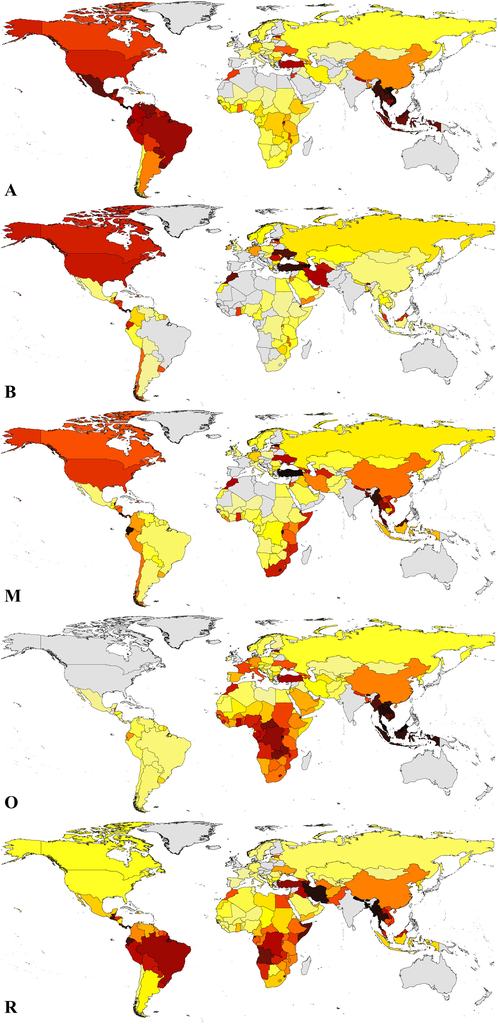

**FIGURE 2**

Percentage overlap between species turnover richness classes denoting changes and non‐coastal administrative boundaries. A = amphibians; B = birds; M = mammals; O = Odonata; R = reptiles. Grey areas show islands or areas where high turnover was not detected on any administrative boundary. Darker hues indicate a high percentage of overlap between non‐coastal boundaries and high levels of turnover in richness, indicating that more species might have ranges delimited by non‐coastal administrative boundaries

Without coastal boundaries included, Northern Southeast Asian boundaries were visible across taxa (excluding birds; Supporting Information Figure S3), with the Chinese side of borders exhibiting much lower diversity than neighbouring Thailand, Vietnam and Myanmar, despite a lack of evidence to support biogeographical shifts across these borders. Iran also showed high turnover along administrative boundaries, considerably below the other areas it borders. What was striking was that for some countries, especially Southeast Asian countries, 100% of non‐coastal boundaries showed overlap with peak areas for species turnover, highlighting the disproportionately large role that these borders play in mapping species distributions (Supporting Information Figure S3).

### 3.2 Species turnover on the boundaries

TABLE 2. Percentage of all species range boundary hotspots (A: top two richness classes of turnover; and B: top three richness classes of turnover) included within buffers of national administrative boundaries

| Species | 500 m | 1,000 m | 2,500 m | 5,000 m |
| --- | --- | --- | --- | --- |
| A. |  |  |  |  |
| Amphibians | 46 | 65 | 74 | 76 |
| Birds | 30 | 44 | 54 | 59 |
| Mammals | 38 | 55 | 64 | 68 |
| Odonata | 48 | 54 | 57 | 61 |
| Reptiles | 30 | 43 | 54 | 58 |
| B. |  |  |  |  |
| Amphibians | 40 | 56 | 64 | 68 |
| Birds | 43 | 63 | 74 | 77 |
| Mammals | 48 | 68 | 79 | 82 |
| Odonata | 45 | 52 | 57 | 62 |
| Reptiles | 35 | 51 | 62 | 66 |

### 3.3 River basins

For Odonata, river basins were used by the specialist group to delineate species range limits (Supporting Information Figure S2b). Consequently, when only the ranges designated by the specialist group were analysed, > 92% of range boundaries fell on river basin boundaries when including a 1 km buffer (Supporting Information Table S1). This was not the case for species recently added to the Odonata dataset (largely in Latin America), which clearly used a different, less spatially precise approach, and only 74.3% of the new boundaries fell on river basin boundaries.

### 3.4 U.S. counties and amphibians

Within the USA, county boundaries were primarily used, with only 2% of the area > 500 m from county borders containing amphibian range limits. In contrast, 20% of county boundaries had > 10 amphibian species range boundaries recorded, and only 31% of all U.S. county borders did not show overlap (Supporting Information Figure S2a). Almost 60% of amphibian species in the USA had all their range boundaries on county borders, and the 40% that showed some of their ranges off county borders included invasive alien species, such as the African clawed frog (*Xenopus laevis*). In addition, many of these species were range restricted, with 20% showing a range < 100 km<sup>2</sup>, 6% < 10 km<sup>2</sup> and 3% < 1 km<sup>2</sup>. Notably, similar low‐level administrative areas were not used in other regions.

### 3.5 Reptiles and grids

The gridding of reptile ranges (Supporting Information Figure S2c) was visible in all countries with high reptile diversity (especially tropical and subtropical areas). Using large (1°, equivalent to 111 km) grids, the density boundaries included 19% of boundaries with three to five species and 63% of boundaries with more than five species. For all large‐grid areas for all global landmasses, 4% had a minimum of three species boundaries in them, which was surprising because most of the globe is low diversity for species that have been mapped. Smaller (55 km) grids included 27% of all boundaries with three to five species and 71% of boundaries with five or more species. This was equivalent to only 2.1% of all small grids across the planet. When this analysis was clipped to areas where three or more species range boundaries were mapped to occur (because two might be simply where range boundaries intersected, but for three or more it is more likely that they follow the same range boundary pattern), these values inflated to 15% of all large‐grid areas with at least three species and 8.3% for small (0.5°) grids.

### 3.6 GBIF versus ERMs

Remarkably, many disagreements existed between GBIF and ERM data, with 80% of taxa having ≥ 30% of their GBIF occurrence points outside of their corresponding ERMs (Table 3). This phenomenon differed in magnitude regionally, with the Palaearctic, Neotropical and Indomalayan regions having > 50% of records outside ERMs on average and the Australasian and Afrotropical regions having between 40 and 50% of localities outside their mapped ranges (Table 3), and others with lower proportions. For species occurring in more than one realm, the number of realms in which a species listed might relate to error, with wider‐ranging species showing a higher percentage of localities outside their mapped realms, and reptiles almost uniformly had the lowest accuracy.

TABLE 3. Percentage of filtered occurrence records outside the expert range map boundaries for each species within each taxon for each of the realms examined

| Realm | Bird | Odonata | Reptiles | Mammals | Amphibians | All |
| --- | --- | --- | --- | --- | --- | --- |
| Total | 25 | 32 | 35 | 34 | 46 | 33 |
| Average | 39 | 59 | 70 | 39 | 52 | 52 |
| Palaearctic | 51 | 68 | 62 | 51 | 33 | 53 |
| Neotropical | 39 | 43 | 73 | 39 | 57 | 50 |
| Indomalayan | 27 | 66 | 77 | 27 | 53 | 50 |
| Afrotropical | 23 | 73 | 71 | 23 | 46 | 47 |
| Australasian | 38 | 24 | 65 | 38 | 48 | 43 |
| Nearctic | 52 | – | 55 | 52 | 36 | 39 |
| Oceania | 30 | – | 90 | 30 | – | 30 |

### Note

- “Total” refers to the percentage of all points falling outside the corresponding expert range map, and “average” is the average percentage of points. Values given for realms represent the average percentage of points outside expert range maps for those taxa and realms for species with realms listed within International Union for Conservation of Nature Red List assessments.

### 3.7 Alternative approaches

In comparing the ERM data with models and polygons derived from the point data, clear differences could be seen (Figure 3), with different filters dramatically changing richness patterns, especially in comparison to the previously modelled richness (Figure 3a). Even untrimmed, MCPs captured the hotspots highlighted by advanced models better than the ERM data, and the ERM maps continued to show clear political borders even when trimmed (Figure 3b,d,e). Too little information existed in the IUCN database for the assessment of many species. After trimming, the MCPs showed much higher richness than either of the two trimmed ERMs, with a maximum of only 18 co‐occurring species for the ERM data based on the limited species assessments possible using only IUCN data (73 species included; Figure 3d). For bats there were ≤ 70 coexisting species from the “integrated assessment” ERM filtered data (260 species; Figure 3e) and 128 species from the MCPs (340 species; Figure 3f). Simple MCPs not only included many more species, but also recreated the patterns recovered by previously published MaxEnt bat richness layer and other published studies better than the ERMs (Li et al., 2019).

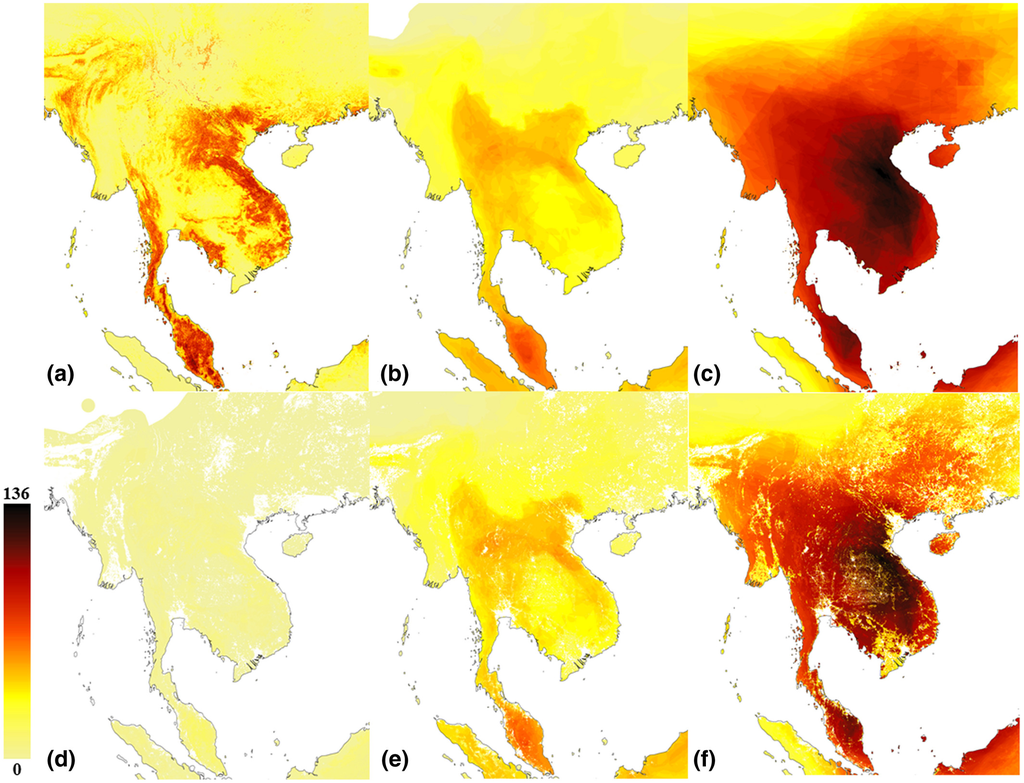

**FIGURE 3**

Different richness maps for bats in Southeast Asia using a variety of approaches and a standardized key denoting species richness to enable direct comparison. (a) MaxEnt‐based model on bats (from Hughes, 2017). (b) IUCN richness for bats without any filters. (c) Minimum convex polygons (MCPs) based on point data used by Hughes (2017) for bats. (d) Filtered IUCN data on bats for species with sufficient data in the IUCN Red List database for trimming by elevation and vegetation type. (e) IUCN data on bats with an integrated filter based on a compilation of IUCN assessments and point data for trimming by elevation and vegetation type. (f) Filtered MCPs based on integrated assessments. Methods for this analysis are shown in the Supporting Information (Figure S1d) complete with the data that were used for each component of the analysis. IUCN = International Union for Conservation of Nature

## 4 DISCUSSION

The aim of ERMs is to provide globally consistent and comparable sources of data for mapping biodiversity and endangerment scalability, comparability and representativeness, because differences in approaches can mean that differences in patterns might reflect methodological differences rather than genuine differences in biodiversity. Yet, for all groups examined, the data fail to meet even these basic expectations. As a consequence of the different approaches used to develop ERMs there are obvious methodological changes, geographical or taxonomic biases, and inconsistencies both within and between taxa. Consequently, meaningful comparison of analyses, especially between regions or taxa, might not be possible using ERMs.

### 4.2 Comparability across and within groups

Amphibian, odonata and reptile maps have separate drivers of spatial bias, and their biases differ both spatially and temporally as a consequence of different methodologies. Consequently, the main benefit of using a single data source is entirely lost, because this inconsistency precludes the attribution of differences between regions or taxa to genuine differences rather than to methodological differences. For example, reptile distribution maps have frequently relied on either 1 or 0.5° grids, with these boundaries clearly detectable on maps of species range boundaries and turnover with, for example, > 71% of range boundaries shared by more than five species falling either on a political boundary or on a 0.5° grid. The fact that grids, political areas and other features are used in a variable manner complicates these issues further. Even for Odonata, where more biologically relevant river basin boundaries are used, the near‐universal use of such features (i.e., 92% of formerly mapped ranges are on river basin boundaries) can still result in inaccurate maps with both type I and type II errors. Thus, although trimming of ERMs with appropriate filters could be applied to most taxa, assessments of gridding for reptiles before such an approach could be applied usefully. For other taxa, once possible political boundaries have been assessed, it might be possible to trim species ranges based on clear assessments of habitat needs.

Regional biases are an especially notable issue; for example, only 31% of U.S. county boundary area (width = 1 km) had no amphibian range boundaries, whereas only 98% of the land > 500 m from a county boundary had no amphibian range boundaries (Supporting Information Figure S2a). These amphibian county biases are the result of a specific initiative within the USA (Blackburn et al., 2001), and such inconsistent standards make comparable analysis between regions impossible. Once U.S. amphibians that have all their boundaries on county borders are removed, only 40% of species remain, and the remainder include range‐restricted and invasive species. Given that county limits do not typically follow ecological boundaries, they clearly do not represent species boundaries. Thus, most forms of trimming could not be used to map ranges or diversity of such groups accurately.

In many cases, the development of published IUCN distributions contradicts their general guidance (IUCN guidelines: [https://www.iucnredlist.org/resources/guidelines‐for‐appropriate‐uses‐of‐red‐list‐data](https://www.iucnredlist.org/resources/guidelines-for-appropriate-uses-of-red-list-data)). Although former IUCN training material ([https://www.iucn.org/content/iucn‐red‐list‐training‐course‐now‐online](https://www.iucn.org/content/iucn-red-list-training-course-now-online)) explicitly specified not to draw buffers around single locality points for building distributions, this has clearly been done for hundreds of species across taxa, extensively for some groups (Supporting Information Figure S2d). In addition to other inconsistent biases both within and across groups, these datasets lose the invaluable comparability that would normally be expected from methods that are standardized temporally, spatially and taxonomically. Consequently, further validation and refinement with verified point data are necessary before these data are used for formal conservation management.

### 4.3 Missing the point: errors of omission need to be solved

The pervasive biases in these datasets are not a new issue. Range overestimations have been explored previously (Brooks et al., 2019), but errors of omission have received comparatively little focus. Researchers seemingly assume that, because models overestimate habitat suitability within their borders, the total area of inhabitance should also be excessive. However, a recent analysis (Li et al., 2019) found that although BirdLife range maps were typically *c*. 10 times the area of predictive models, ERMs still missed areas with recorded, verified records, potentially highlighting areas of limited value whilst missing key areas that species might require to survive. We found the same issue in our analyses; even in the best‐studied group (birds), 25% of records fall outside individual ERMs on average, and ≤ 46% of records for other groups. This varies significantly between regions, with ≤ 90% of records for reptiles in oceanic zones potentially falling outside their ERMs. When we average for each region, rather than across all data (which emphasizes better‐sampled regions in the West), the average accuracy of the results drops for most groups such that many mapped ranges are spatially incorrect; hence, they might misdirect conservation efforts. Altogether, these issues can lead to entirely incorrect estimates of biodiversity hotspots, as seen when comparing the validated models (Hughes, 2017), which showed that ERM hotspots were much larger (≤ 40% of the region for some groups relative to ≤ 5% for models: Li et al., 2019). Despite this, ERMs still failed to capture 15% of the most diverse hotspots according to models and might actively hinder effective conservation efforts by overestimating some and missing other key biodiversity regions. Thus, at least in developing and tropical regions, these errors in ERMs mean that aggregating distribution data and trimming MCPs based on environmental factors might map species ranges more accurately and have a lower probability of omission.

Crucial hotspots in transboundary areas are particularly likely to be overlooked and missed owing to these issues, because some borders show particularly high purported species turnover based on ERM analyses (Figure 2; Supporting Information Figure S3). These issues further complicate pre‐existing challenges with working in close vicinity to many political boundaries. Already, transboundary conservation assessments and recommendations are being made based on these data (Mason et al., 2020). These concerns are even more important for rare and range‐limited species, which cannot necessarily be protected merely by conserving more charismatic megafauna. One consequence is that the largest taxa are often removed from analyses. For example, some analyses have used only 8% of mammal species (Visconti et al., 2016), the rough equivalent of assessing plants without angiosperms. Further efforts are needed to increase the breadth and empiricism underlying ERMs and to ensure that data‐driven analyses are applied to remove such biases.

Climate change presents an especially large challenge for analyses using ERMs. As we demonstrate, biases on borders, especially the South China border, are particularly problematic with, for example, a change in 60 bat species shown across a few kilometres (Supporting Information Figure S4), which is not supported by local data (Figure 3). In recent studies, it has been hypothesized that dramatic changes in community composition resulting from climate change could have caused severe acute respiratory syndrome coronavirus 2 to emerge (Beyer et al., 2021), but this perceived shift in community composition is purely an artefact of this perceived change in species present, and various coronaviruses are known to be present in bats of the region independently (Zhou et al., 2020). Given that these perceived changes in diversity are common at borders, studies on climate change, particularly with implications for disease and human health, must proceed with extreme caution, because improper analyses can lead to inaccurate outcomes and possible misinformed, possibly detrimental, policy actions.

### 4.4 Finding a reliable and accurate solution

Given the difficulty of acquiring verified point data across all species, many researchers modify ERMs to justify mapping diversity at higher resolutions or “accuracy”. A common method is to trim species ranges by habitat and elevational range (Brooks et al., 2019; Li et al., 2016; Ocampo‐Peñuela et al., 2016). Yet, to do so universally makes a number of critical errors and fails to address the root causes of issues in such analyses.

These new approaches do not account for spatial biases associated with administrative boundaries or the missing of key areas (highlighted above). In addition, although refining by habitat is sensible if species are well known, such data exist for relatively few species. As an example, clipping by elevation makes assumptions about the level of knowledge on species ranges, although defining the true elevational ranges of species is challenging and uncertain for many species. Furthermore, inconsistency of the data across species ranges cannot be accounted for; for example, there is likely to be a relationship between elevation range and latitude for most species with large ranges, and these may shift seasonally. Basically, ranges will vary by latitude and might not be known for most species. Additionally, current minimum ranges do not necessarily represent climate‐based ecophysiological thresholds for species, because lower‐elevation range limits are most vulnerable to being converted to other types of land use and to other disturbances. However, our occurrence point data showed that many species listed as mid or high elevation by the IUCN had also been recorded at sea level; thus, current IUCN assessments might overlook areas of the range without evaluating what data are available. Our analysis showed that species ranges regularly fell over a much broader area than in ERM assessments even when such a listing was given, and that estimates of range without sufficient data falsely represent true species ranges. Thus, basing future projections on thresholds generated by ERMs will overinflate the perceived vulnerability of species by effectively removing higher‐temperature areas that might even be optimal for some species. For these reasons, clipping an “expert‐generated map” with “expert knowledge on species ranges” (i.e., elevational range) might amplify biases, especially when species have lost habitat or other areas might be undersampled.

Data‐driven alternatives with sensible uncertainty measures should be developed, especially given that most range maps clearly disobey current guidance. A better approach is to use data of species localities sensibly to develop predictions of where species are known to occur, restrict extrapolation to the country or island where localities exist and use these predicted ranges as a replacement for “expert range maps”. Such initiatives could also be used to drive data aggregation and sharing, maximizing the availability of open data such as those made available through GBIF (although careful error checking is needed; Orr et al., 2020). Given that such data biases are well known in GBIF, further digitization and data‐sharing efforts will be key. To grow these resources further, mechanisms must also be developed to fund taxonomic data verifications and museum data digitization better, also including mandated data sharing for projects receiving this funding (Orr et al., 2021). Such data are more likely to capture less‐accessible areas and rarer species than data generated by citizen scientists, making them invaluable for generating a representative view of the natural world (Hughes et al., 2020).

Here, we show that ERMs are biased and inconsistently delineated across space and taxa, and that even simple approaches, such as MCPs, produce more realistic diversity models. Trimming, which can be streamlined into a reproducible approach and applied in a standardized way across species (Figure 3), improves the performance of MCPs further, whereas many shortcomings in ERMs are not ameliorated. As a basis for regional conservation, the data now exist for many taxa to have such data‐driven approaches, whereas continued use of range maps without careful bias management could misdirect conservation attention.

### 4.5 Looking forwards

As a scientific community, we should have moved past manually drawing maps of where we assume species to be, yet such maps still form the basis of almost all global and regional assessments on biodiversity. Here, we demonstrate that inherent and inconsistent biases within and between these datasets arise from the use of administrative or other convenient boundaries to demarcate species limits, missing up to half the records of many species. Such approaches will lead to incorrect assessments of species vulnerability, potentially highlighting the wrong areas for conservation or management for both single species and communities, especially where transitioning from tropical to subtropical or temperate areas.

Although these ERMs were adequate when data were unavailable, initiatives for data digitization and sharing are finally gaining traction as more high‐resolution satellite data have become available. Methodological approaches that enable the modelling of species ranges based on data‐driven approaches such as those shown here are more representative of reality. Expert knowledge has a crucial role in developing and testing such analyses and in developing standard frameworks to ensure that outputs are meaningful; however, we have reached a point where we can begin to develop truly automated, standardized approaches to inform conservation. We can no longer rely on inconsistent or biased datasets, because doing so limits efforts to digitize real point data and develop new approaches, and conservation advice should no longer rely entirely on these types of expert data alone.

## COMPETING INTERESTS

The authors declare that there are no competing interests.

## ACKNOWLEDGMENTS

A.C.H. was supported by the Chinese National Natural Science Foundation (U1602265, Mapping Karst Biodiversity in Yunnan), the Strategic Priority Research Program of the Chinese Academy of Sciences (XDA20050202), the High‐End Foreign Experts Program of Yunnan Province (Y9YN021B01, Yunnan Bioacoustic Monitoring Program), the CAS 135 program (2017XTBG‐T03) and the Chinese Academy of Sciences Southeast Asia Biodiversity Research Center fund (Y4ZK111B01). M.C.O. was supported by the Strategic Priority Research Program of the Chinese Academy of Sciences (XDB310304), the National Science Foundation of China International Young Scholars Program (31850410464) and the Chinese Academy of Sciences President's International Fellowship Initiative (2018PB0003 and 2020PB0142). Q.J. was supported by the Chinese National Natural Science Foundation (31772432) and the Ningxia Hui Autonomous Region Agricultural Science and Technology Independent Innovation Fund (NGSB20211405).

## AUTHOR CONTRIBUTIONS

A.C.H. and H.Q. conceptualized the paper. A.C.H., Q.Y. and H.Q. prepared and analysed the data. A.C.H. and M.C.O. drafted the initial manuscript. All authors edited and revised the manuscript and suggested additional analysis. All authors agreed to the submission of the manuscript.

### Details

© 2021 John Wiley & Sons Ltd

[figure not shown]

### Research funding

- Chinese National Natural Science Foundation. Grant Numbers: U1602265, 31772432
- Chinese Academy of Sciences. Grant Number: XDA20050202
- High‐End Foreign Experts Program of Yunnan Province. Grant Number: Y9YN021B01
- Chinese Academy of Sciences Southeast Asia Biodiversity Research Center fund. Grant Number: Y4ZK111B01
- CAS President's International Fellowship Initiative. Grant Numbers: 2018PB0003, 2020PB0142
- Ningxia Hui Autonomous Region Agricultural Science and Technology. Grant Number: NGSB20211405

### Keywords

- [Accuracy assessment](https://onlinelibrary.wiley.com/action/doSearch?field1=Keyword&text1=Accuracy%20assessment)
- [biodiversity mapping](https://onlinelibrary.wiley.com/action/doSearch?field1=Keyword&text1=biodiversity%20mapping)
- Birdlife
- [spatial ecology](https://onlinelibrary.wiley.com/action/doSearch?field1=Keyword&text1=spatial%20ecology)
- [species range maps](https://onlinelibrary.wiley.com/action/doSearch?field1=Keyword&text1=species%20range%20maps)
- UCN

### Publication History

- Version of Record online: 22 April 2021
- Manuscript accepted: 23 March 2021
- Manuscript revised: 18 March 2021
- Manuscript received: 04 September 2020